# Electronic Community Health Information System Monthly Report - May 2023

Ministry of Health

[figure not shown]

This is a monthly statistical update generated with data from the electronic Community Health Information System. This system is currently deployed in 9 districts, supporting **2,912 VHTs** as seen below.

**Achievements in May 2023**

- National Training of Trainers for 60 master trainers in Jinja
- District Health Team Trainings for 50 DHTs in Ntugamo and 40 in Lamwo
- Onboarding of 801 VHTs on to eCHIS in Ntugamo Districts.
- Integration of the WASH MIS into eCHIS.
- Refresher Trainings in all West Nile, Lango, and Acholi
- Pilot of the Translated eCHIS in Buikwe.
- Review of the Immunisation Workflows in eCHIS.
- CHT Stakeholders Engagements
- OpenSRP user acceptance Test held in Soroti.

[figure not shown]

State of the eCHIS Roll Out

## 0.1 Reporting Rate

This is Calculated as the Actual Reports received as the numerator and Expected Reports as the Denominator.

### 0.1.1 National Trend - Reporting Rates for eCHIS

The current national Reporting Rate is 56. The drop is due to the recent onboarding of 801 VHTs in ntugamo to eCHIS.

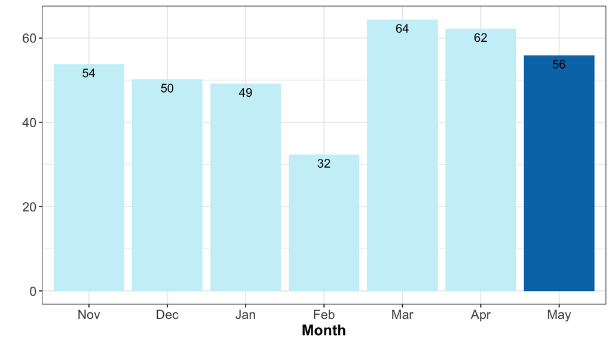

Trend in eCHIS Reporting Rates per District December 2022 to May 2023

| District | Dec | Jan | Feb | Mar | April | May |
| --- | --- | --- | --- | --- | --- | --- |
| Lira | 59 | 69 | 38 | 73 | 82 | 92 |
| Lamwo | 96 | 92 | 62 | 86 | 75 | 77 |
| Nebbi | 52 | 38 | 24 | 64 | 73 | 73 |
| Buikwe | 29 | 49 | 32 | 47 | 62 | 68 |
| Oyam | 50 | 68 | 48 | 62 | 48 | 56 |
| Maracha | 35 | 35 | 21 | 56 | 61 | 53 |
| Koboko | 31 | 36 | 19 | 72 | 59 | 50 |
| Ntungamo | 93 | 89 | 77 | 88 | 86 | 24 |
| Amuru | 16 | 10 | 5 | 8 | 10 | 14 |

Districts - Reporting Rates for eCHIS

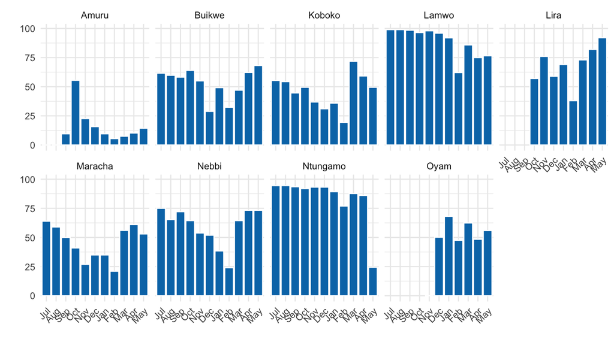

## 0.2 House Holds Registered

**National Trend**

To date , a total of 121665 House Holds have been registered and being supported by VHTs using the eCHIS

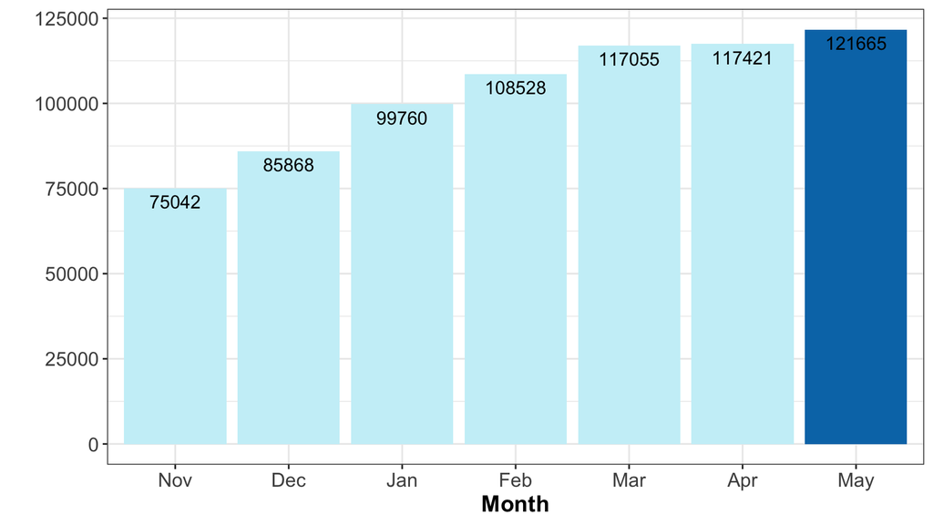

Number of Households Registered per District

| District | Dec | Jan | Feb | Mar | April | May |
| --- | --- | --- | --- | --- | --- | --- |
| Buikwe | 27.53K | 39.56K | 47.95K | 55.54K | 55.41K | 56.84K |
| Ntungamo | 18.15K | 18.22K | 18.24K | 18.29K | 18.33K | 20.37K |
| Nebbi | 7.7K | 7.71K | 7.71K | 7.74K | 7.88K | 7.94K |
| Lamwo | 7.51K | 7.53K | 7.53K | 7.57K | 7.57K | 7.6K |
| Maracha | 6.75K | 6.76K | 6.77K | 6.84K | 6.89K | 6.93K |
| Koboko | 6.18K | 6.18K | 6.2K | 6.25K | 6.28K | 6.31K |
| Lira | 5.32K | 5.34K | 5.35K | 5.46K | 5.52K | 5.64K |
| Oyam | 2.35K | 4.06K | 4.38K | 4.96K | 5.12K | 5.45K |
| Amuru | 4.38K | 4.4K | 4.4K | 4.41K | 4.42K | 4.59K |

## 0.3 Mortality

### 0.3.1 Total Counts of Deaths Under 5 Registered in the eCHIS

To date a Total of 266 deaths under 5 years have been reported in the eCHIS.

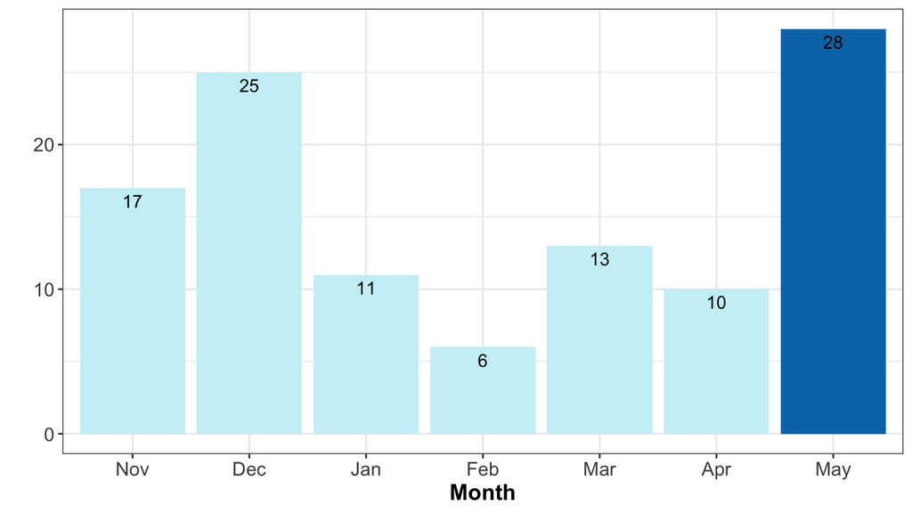

Deaths reported in eCHIS Per District

| District | Dec | Jan | Feb | Mar | April | May |
| --- | --- | --- | --- | --- | --- | --- |
| Buikwe | 16 | 6 | 3 | 6 | 6 | 18 |
| Oyam | 3 | 3 | 2 | 0 | 0 | 5 |
| Maracha | 0 | 0 | 0 | 0 | 1 | 2 |
| Lamwo | 0 | 0 | 1 | 0 | 1 | 1 |
| Lira | 0 | 1 | 0 | 1 | 1 | 1 |
| Ntungamo | 4 | 1 | 0 | 4 | 1 | 1 |
| Amuru | 0 | 0 | 0 | 0 | 0 | 0 |
| Koboko | 1 | 0 | 0 | 0 | 0 | 0 |
| Nebbi | 1 | 0 | 0 | 2 | 0 | 0 |

## 0.4 Malaria

Number of children under 5 seen with Fever

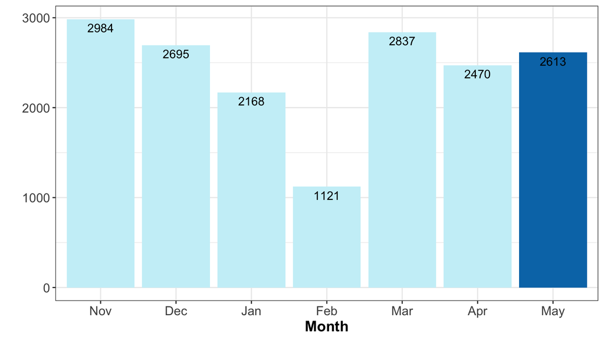

Number of Children with Fever who recieved an RDT

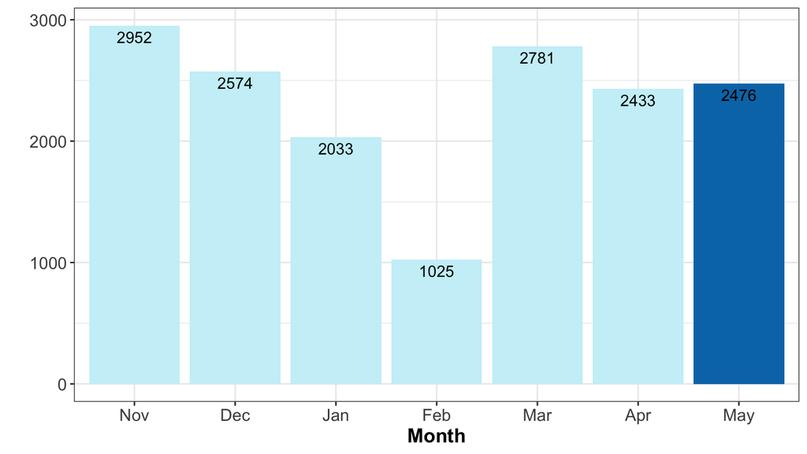

Number of Children Presented with Fever

| District | Dec | Jan | Feb | Mar | April | May |
| --- | --- | --- | --- | --- | --- | --- |
| Buikwe | 801 | 847 | 544 | 845 | 725 | 942 |
| Oyam | 184 | 198 | 148 | 605 | 514 | 515 |
| Lamwo | 853 | 451 | 165 | 723 | 548 | 417 |
| Ntungamo | 512 | 459 | 208 | 345 | 310 | 282 |
| Nebbi | 151 | 90 | 26 | 103 | 116 | 229 |
| Maracha | 87 | 79 | 8 | 120 | 181 | 132 |
| Koboko | 35 | 26 | 14 | 44 | 44 | 54 |
| Lira | 7 | 4 | 4 | 14 | 14 | 35 |
| Amuru | 65 | 14 | 4 | 38 | 18 | 7 |

Children under 5 presenting with fever that got an RDT

| District | Dec | Jan | Feb | Mar | April | May |
| --- | --- | --- | --- | --- | --- | --- |
| Buikwe | 795 | 833 | 522 | 833 | 717 | 918 |
| Oyam | 162 | 149 | 124 | 604 | 501 | 453 |
| Lamwo | 806 | 386 | 118 | 707 | 543 | 402 |
| Ntungamo | 479 | 458 | 208 | 335 | 305 | 268 |
| Nebbi | 144 | 85 | 26 | 100 | 114 | 226 |
| Maracha | 87 | 79 | 8 | 118 | 181 | 132 |
| Koboko | 31 | 24 | 12 | 34 | 42 | 44 |
| Lira | 4 | 5 | 4 | 12 | 12 | 26 |
| Amuru | 66 | 14 | 3 | 38 | 18 | 7 |

Percentage of Children who were confirmed with Malaria using RDTs - National Trend

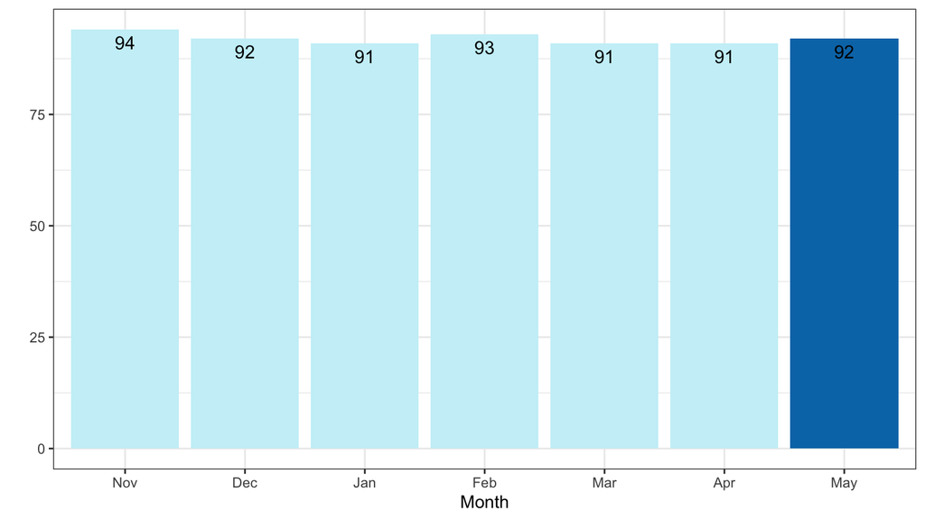

By District

Number of Cases Confirmed with Malaria

| District | Dec | Jan | Feb | Mar | April | May |
| --- | --- | --- | --- | --- | --- | --- |
| Buikwe | 723 | 760 | 491 | 762 | 624 | 759 |
| Oyam | 139 | 127 | 115 | 544 | 462 | 416 |
| Lamwo | 745 | 363 | 110 | 632 | 513 | 374 |
| Nebbi | 140 | 76 | 24 | 93 | 104 | 207 |
| Ntungamo | 354 | 313 | 133 | 235 | 221 | 194 |
| Maracha | 84 | 79 | 8 | 109 | 165 | 126 |
| Koboko | 29 | 22 | 12 | 31 | 41 | 42 |
| Lira | 3 | 2 | 2 | 7 | 8 | 16 |
| Amuru | 65 | 14 | 2 | 35 | 16 | 7 |

Percentage of Children confirmed with Malaria with an RDT that received Coartem

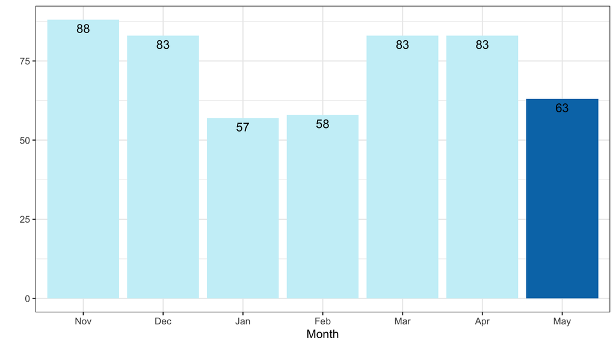

Confirmed Cases that recieved Coartem

| District | Dec | Jan | Feb | Mar | April | May |
| --- | --- | --- | --- | --- | --- | --- |
| Buikwe | 669 | 708 | 455 | 645 | 515 | 534 |
| Oyam | 52 | 39 | 62 | 500 | 418 | 328 |
| Lamwo | 569 | 163 | 42 | 583 | 456 | 217 |
| Ntungamo | 205 | 212 | 97 | 169 | 169 | 122 |
| Nebbi | 118 | 43 | 14 | 44 | 36 | 116 |
| Maracha | 72 | 63 | 6 | 105 | 157 | 111 |
| Koboko | 24 | 17 | 11 | 18 | 32 | 30 |
| Lira | 1 | 0 | 1 | 2 | 3 | 5 |
| Amuru | 60 | 5 | 0 | 29 | 15 | 3 |

## 0.5 Pneumonia

### 0.5.1 Number of children with Fast Breathing Seen by VHTs

To date , a Total of 11346 children have presented with Fast Breathing and managed by VHTs.

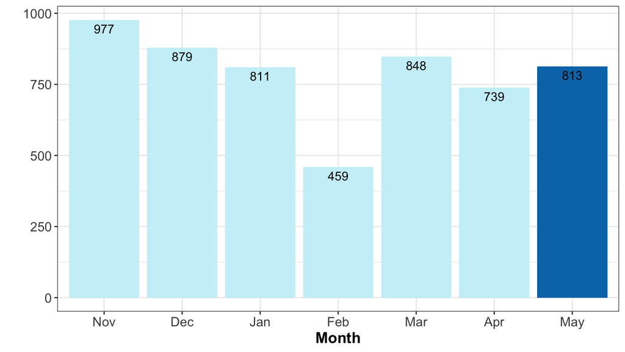

Percentage of Children under 5 with Fast Breathing that Received Oral Amoxicillin

[figure not shown]

% children presenting with Fast Breathing that recieved Amoxillicin

| District | Dec | Jan | Feb | Mar | April | May |
| --- | --- | --- | --- | --- | --- | --- |
| Amuru | 100 | NA | NA | 100 | 100 | 100 |
| Koboko | 0 | 100 | 100 | 100 | 88 | 100 |
| Maracha | 100 | 100 | NA | 62 | 50 | 100 |
| Ntungamo | 75 | 100 | 100 | 100 | 100 | 100 |
| Lira | 100 | 50 | 50 | 100 | 0 | 25 |
| Buikwe | 50 | 60 | 0 | 0 | 2 | 0 |
| Lamwo | 75 | 0 | 0 | 0 | 0 | 0 |
| Nebbi | 42 | 0 | 100 | 0 | 0 | 0 |
| Oyam | 0 | 0 | 0 | 0 | 0 | 0 |

## 0.6 Diarrhoea

Number of Children seen with Diarrhea by the VHTs

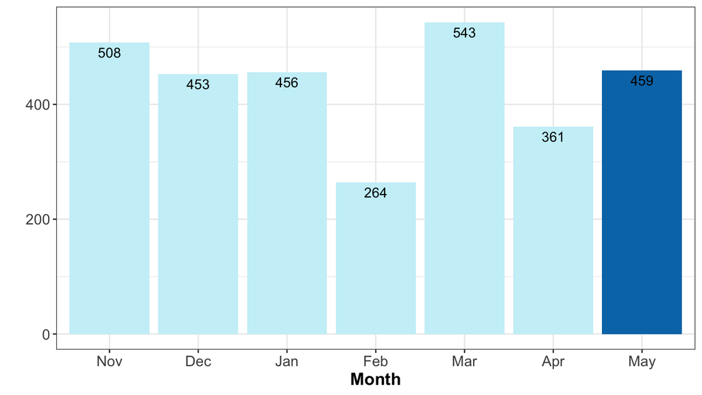

Percentage of Children with Diarrhea who Received ORS - National

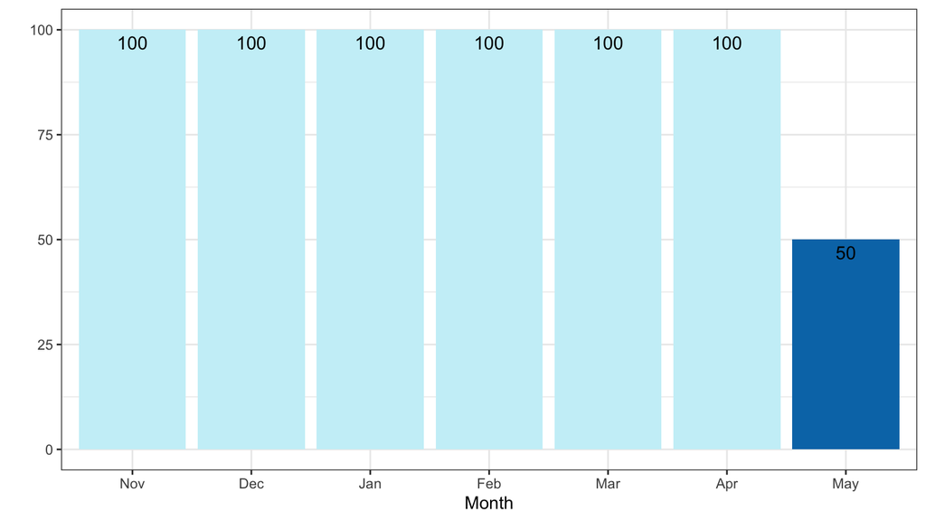

Percentage of Children with Diarrhea who Received ORS

| District | Dec | Jan | Feb | Mar | April | May |
| --- | --- | --- | --- | --- | --- | --- |
| Amuru | 67 | 88 | NA | 75 | 100 | 100 |
| Koboko | 0 | NA | 0 | 0 | 0 | 100 |
| Maracha | 100 | 100 | 50 | 0 | 100 | 100 |
| Nebbi | 100 | 0 | 100 | 0 | 100 | 100 |
| Ntungamo | 100 | 100 | 100 | 100 | 100 | 100 |
| Oyam | 100 | 83 | 0 | 100 | 100 | 100 |
| Lira | 0 | 0 | NA | 0 | 100 | 75 |
| Lamwo | 100 | 50 | 0 | 100 | 100 | 14 |
| Buikwe | 100 | 100 | 100 | 50 | 50 | 0 |

## 0.7 Pregnancy

Home Deliveries

To date , a total of 226 mothers have been registered to a have delivered from Home.

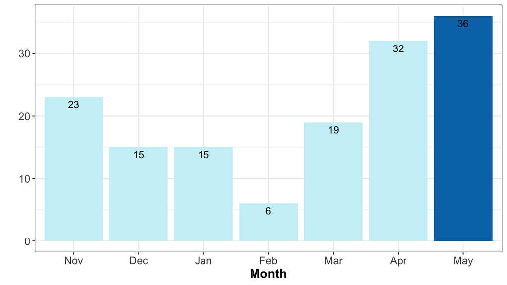

Number of Deliveries at home by District

| District | Dec | Jan | Feb | Mar | April | May |
| --- | --- | --- | --- | --- | --- | --- |
| Buikwe | 0 | 0 | 0 | 2 | 12 | 18 |
| Ntungamo | 2 | 6 | 1 | 5 | 2 | 7 |
| Lira | 9 | 7 | 1 | 4 | 8 | 3 |
| Nebbi | 0 | 0 | 0 | 4 | 4 | 3 |
| Maracha | 0 | 0 | 0 | 0 | 3 | 2 |
| Oyam | 2 | 1 | 1 | 3 | 0 | 2 |
| Amuru | 0 | 1 | 0 | 0 | 0 | 1 |
| Koboko | 2 | 0 | 2 | 1 | 1 | 0 |
| Lamwo | 0 | 0 | 1 | 0 | 2 | 0 |

### 0.7.1 Maternal Deaths

A total of 8 have been reported to have passed on during and after delivery

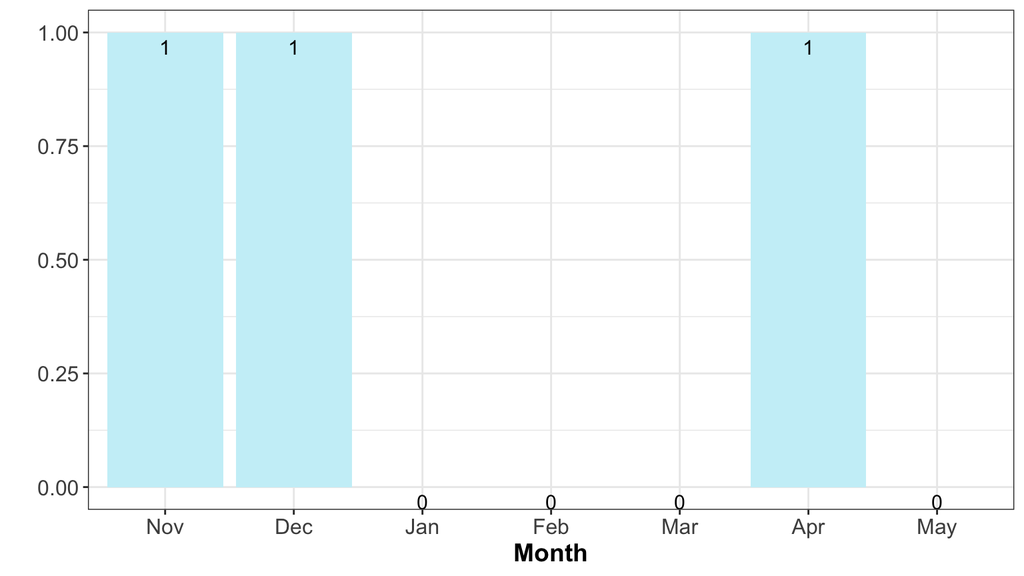

Number of Maternal Deaths at home by District

| District | Dec | Jan | Feb | Mar | April | May |
| --- | --- | --- | --- | --- | --- | --- |
| Amuru | 0 | 0 | 0 | 0 | 0 | 0 |
| Buikwe | 0 | 0 | 0 | 0 | 0 | 0 |
| Koboko | 1 | 0 | 0 | 0 | 0 | 0 |
| Lamwo | 0 | 0 | 0 | 0 | 1 | 0 |
| Lira | 0 | 0 | 0 | 0 | 0 | 0 |
| Maracha | 0 | 0 | 0 | 0 | 0 | 0 |
| Nebbi | 0 | 0 | 0 | 0 | 0 | 0 |
| Ntungamo | 0 | 0 | 0 | 0 | 0 | 0 |
| Oyam | 0 | 0 | 0 | 0 | 0 | 0 |

ANC 4th Visit National Trends

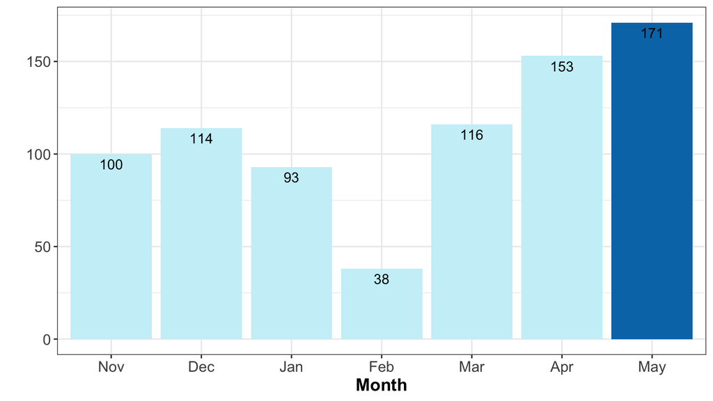

Counts of ANC 4th Visit National Trends

| District | Dec | Jan | Feb | Mar | April | May |
| --- | --- | --- | --- | --- | --- | --- |
| Buikwe | 0 | 0 | 0 | 50 | 68 | 75 |
| Ntungamo | 24 | 20 | 8 | 16 | 16 | 31 |
| Nebbi | 9 | 8 | 6 | 4 | 18 | 16 |
| Koboko | 5 | 8 | 3 | 16 | 5 | 13 |
| Oyam | 50 | 37 | 6 | 12 | 9 | 11 |
| Amuru | 1 | 1 | 0 | 2 | 10 | 8 |
| Lamwo | 8 | 9 | 13 | 6 | 10 | 8 |
| Lira | 5 | 6 | 1 | 7 | 3 | 8 |
| Maracha | 12 | 4 | 1 | 3 | 14 | 1 |

## 0.8 WASH

There might be to further analyse the WASH Indicators to make sense of the state in the community.

## 0.9 Nutrition

To date a total of 60559 Nutrition screenings have happened

Number of children Screened

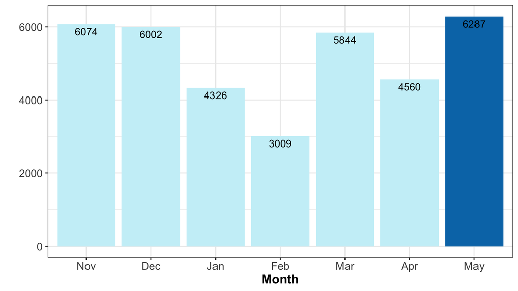

By District

Number of Children < 5 Screened for Malnutrition

| District | Dec | Jan | Feb | Mar | April | May |
| --- | --- | --- | --- | --- | --- | --- |
| Ntungamo | 3.32K | 2.21K | 1.74K | 2.85K | 1.95K | 2.81K |
| Buikwe | 1.1K | 1.02K | 715 | 1.09K | 1.09K | 1.89K |
| Oyam | 214 | 268 | 213 | 655 | 532 | 553 |
| Lamwo | 1.01K | 576 | 265 | 848 | 587 | 470 |
| Nebbi | 152 | 107 | 25 | 114 | 123 | 234 |
| Maracha | 89 | 90 | 16 | 143 | 184 | 132 |
| Lira | 15 | 6 | 20 | 42 | 26 | 127 |
| Koboko | 37 | 31 | 16 | 61 | 53 | 57 |
| Amuru | 64 | 14 | 3 | 38 | 17 | 10 |

Number of Children Screened with Yellow MUAC

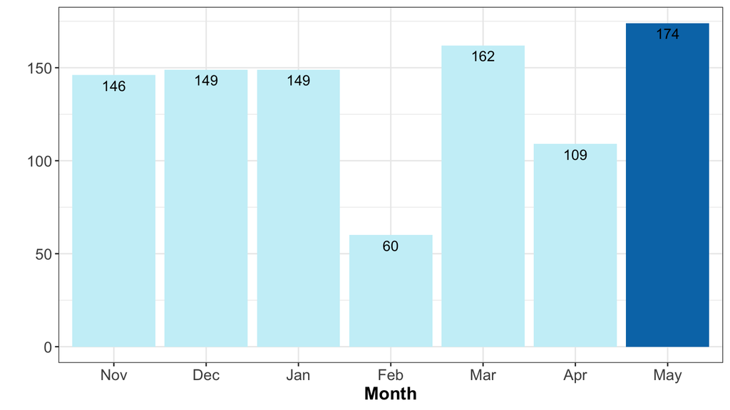

Children < 5 found with a Yellow MUAC

| District | Dec | Jan | Feb | Mar | April | May |
| --- | --- | --- | --- | --- | --- | --- |
| Buikwe | 44 | 47 | 25 | 55 | 38 | 65 |
| Ntungamo | 51 | 45 | 18 | 46 | 24 | 48 |
| Lira | 4 | 3 | 0 | 7 | 9 | 28 |
| Oyam | 10 | 17 | 8 | 23 | 18 | 16 |
| Lamwo | 37 | 34 | 9 | 23 | 11 | 7 |
| Nebbi | 1 | 0 | 0 | 1 | 2 | 5 |
| Amuru | 1 | 2 | 0 | 1 | 0 | 4 |
| Koboko | 1 | 0 | 0 | 3 | 4 | 1 |
| Maracha | 0 | 1 | 0 | 3 | 3 | 0 |

Children Assessed who had a Red Muac

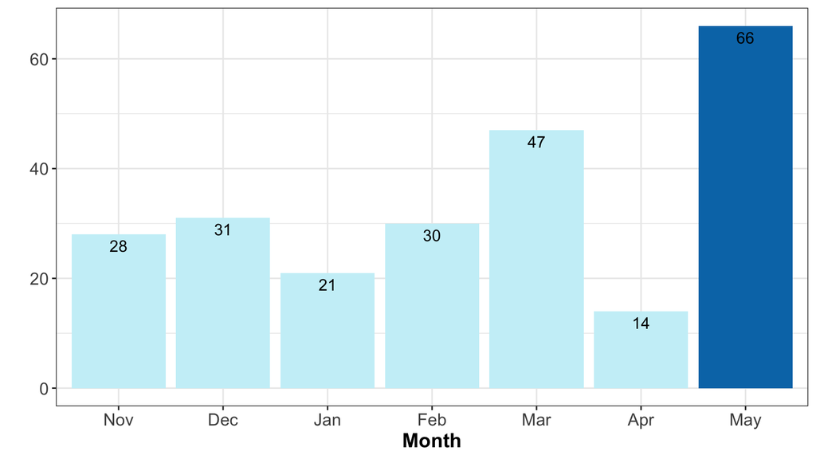

Children < 5 Assessed who had a Red Muac

| District | Dec | Jan | Feb | Mar | April | May |
| --- | --- | --- | --- | --- | --- | --- |
| Buikwe | 5 | 6 | 3 | 8 | 5 | 20 |
| Lira | 0 | 0 | 16 | 15 | 2 | 19 |
| Ntungamo | 25 | 8 | 9 | 7 | 4 | 18 |
| Oyam | 1 | 7 | 1 | 11 | 1 | 6 |
| Lamwo | 0 | 0 | 0 | 4 | 1 | 2 |
| Nebbi | 0 | 0 | 0 | 2 | 1 | 1 |
| Amuru | 0 | 0 | 1 | 0 | 0 | 0 |
| Koboko | 0 | 0 | 0 | 0 | 0 | 0 |
| Maracha | 0 | 0 | 0 | 0 | 0 | 0 |

Children Assessed Presenting with Odema

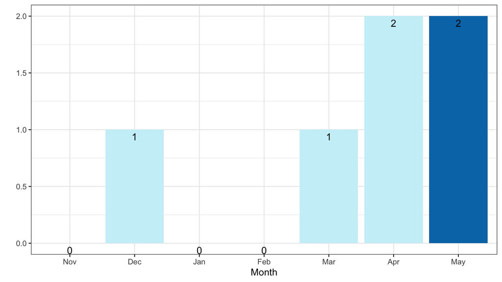

[output not shown]

## 0.10 Immunisation

## 0.11 HIV / TB

### 0.11.1 HIV/AIDS

National Trend in Counts of Children exposed to HIV

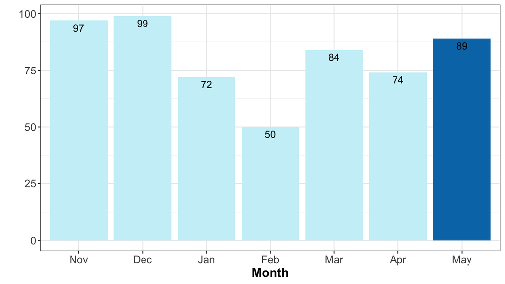

Counts of children exposed to HIV

| District | Dec | Jan | Feb | Mar | April | May |
| --- | --- | --- | --- | --- | --- | --- |
| Buikwe | 27 | 23 | 16 | 14 | 28 | 33 |
| Ntungamo | 46 | 29 | 18 | 39 | 20 | 30 |
| Oyam | 4 | 9 | 10 | 8 | 12 | 12 |
| Lamwo | 17 | 11 | 5 | 17 | 9 | 7 |
| Lira | 0 | 0 | 0 | 2 | 1 | 4 |
| Nebbi | 3 | 0 | 1 | 0 | 2 | 2 |
| Amuru | 2 | 0 | 0 | 3 | 0 | 1 |
| Koboko | 0 | 0 | 0 | 0 | 0 | 0 |
| Maracha | 0 | 0 | 0 | 1 | 2 | 0 |

National Trend in Counts of People living with HIV not on Treatment

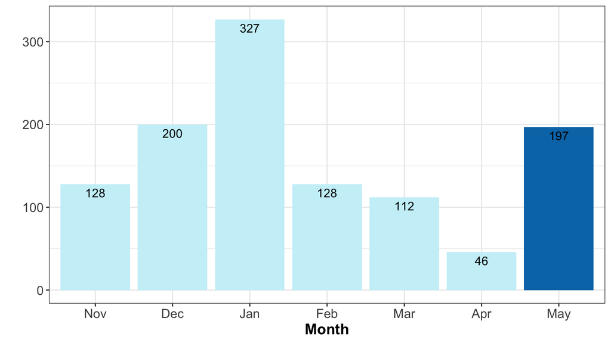

District Trend in counts of People living with HIV not on Treatment

People living with HIV not on Treatment

| District | Dec | Jan | Feb | Mar | April | May |
| --- | --- | --- | --- | --- | --- | --- |
| Ntungamo | 59 | 20 | 50 | 32 | 6 | 127 |
| Buikwe | 86 | 286 | 63 | 47 | 27 | 48 |
| Lira | 2 | 0 | 0 | 0 | 1 | 7 |
| Amuru | 6 | 0 | 2 | 1 | 0 | 5 |
| Lamwo | 4 | 0 | 4 | 10 | 1 | 4 |
| Oyam | 39 | 20 | 6 | 19 | 5 | 3 |
| Nebbi | 1 | 1 | 2 | 2 | 2 | 2 |
| Maracha | 3 | 0 | 0 | 0 | 4 | 1 |
| Koboko | 0 | 0 | 1 | 1 | 0 | 0 |

### 0.11.2 Tuberculosis

National Trend in Counts of Children exposed to Tuberculosis

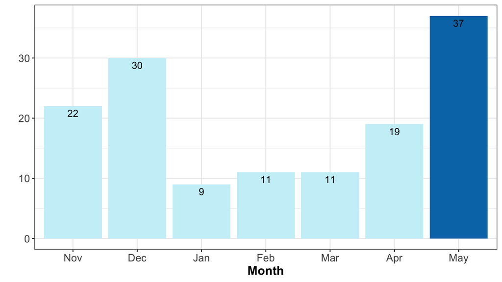

Counts of children exposed to TB

| District | Dec | Jan | Feb | Mar | April | May |
| --- | --- | --- | --- | --- | --- | --- |
| Buikwe | 5 | 1 | 3 | 7 | 5 | 21 |
| Ntungamo | 14 | 3 | 4 | 3 | 5 | 7 |
| Nebbi | 0 | 0 | 0 | 0 | 2 | 3 |
| Lamwo | 3 | 1 | 1 | 0 | 3 | 2 |
| Oyam | 5 | 4 | 3 | 1 | 1 | 2 |
| Amuru | 2 | 0 | 0 | 0 | 0 | 1 |
| Lira | 0 | 0 | 0 | 0 | 1 | 1 |
| Koboko | 1 | 0 | 0 | 0 | 0 | 0 |
| Maracha | 0 | 0 | 0 | 0 | 2 | 0 |

National Trend in Counts of People living with Tuberculosis not on Treatment

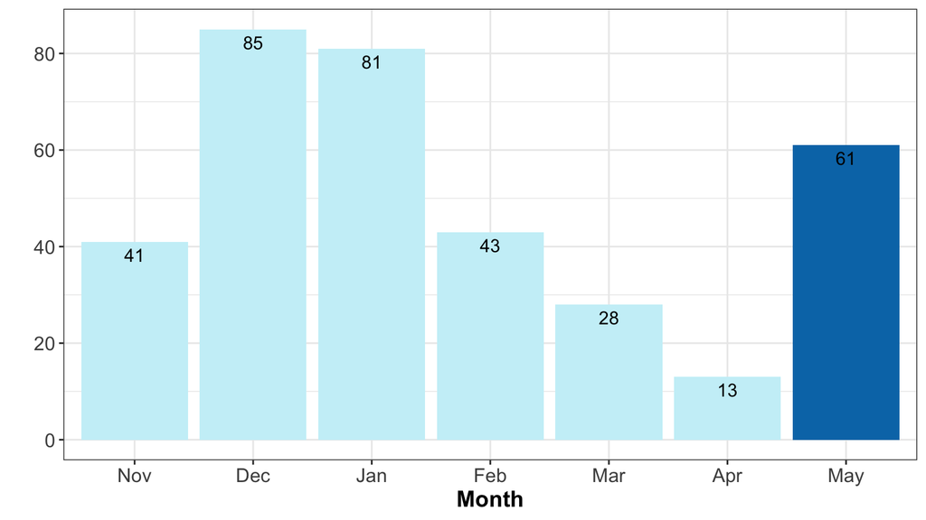

People living with TB not on Treatment

| District | Dec | Jan | Feb | Mar | April | May |
| --- | --- | --- | --- | --- | --- | --- |
| Buikwe | 47 | 71 | 35 | 18 | 7 | 29 |
| Ntungamo | 14 | 3 | 2 | 3 | 2 | 16 |
| Amuru | 3 | 0 | 0 | 0 | 0 | 4 |
| Lamwo | 4 | 1 | 1 | 1 | 3 | 4 |
| Lira | 0 | 1 | 0 | 2 | 0 | 4 |
| Oyam | 16 | 5 | 5 | 1 | 1 | 4 |
| Koboko | 0 | 0 | 0 | 0 | 0 | 0 |
| Maracha | 0 | 0 | 0 | 2 | 0 | 0 |
| Nebbi | 1 | 0 | 0 | 1 | 0 | 0 |

## 0.12 Stock Status

This data is undergoing review so as optimize use